# NYCFlights: Arrival Delay Regression Model

Nimish Kulkarni

Oct 16, 2016

# NYCFlights Model

Using the rectangular data that you created last week and following the *Predicting Medical Expenses* example from the text (*MLwR*), create a model for arr_delay. Follow MLwR structure for building a model. Describe/Explain each of the steps and show all work in codeblocks below.

## Step 1: Collect Data

```r
# Data Frames

flights  <- "../data/flights.csv" %>% read_csv
planes   <- read_csv("../data/planes.csv")
airports <- read_csv("../data/airports.csv")
weather  <- read_csv("../data/weather.csv")
# Merging Data Frames
YX <- flights

## planes
YX <- merge( YX, planes, by="tailnum", all.x = TRUE )

## airports
YX <- merge(YX, airports, by.x="origin", by.y="faa", all.x=TRUE, suffixes=c("", ".origin")  )
YX <- merge(YX, airports, by.x="dest", by.y="faa", all.x=TRUE, suffixes=c("", ".dest")  )

## weather
# weather$date <- ymd(weather$year, weather$month, weather$day)
YX <-
  merge( flights, weather, by=c("origin","year","month","day","hour"), all.x=TRUE, suffixes=c('',".weather") )

## clearing the console screen
cat("\014")
```

## Step 2: Explore and Prep The Data

One of the things not done in the MLwR text is a pairwise comparison between the response and each of the predictors. Make sure to do this; this is often very illustrative of the relationship between that predictor and the response. This can be done with `pairs` or `psych::panel.pairs`

```r
str(YX)
```

```
## 'data.frame':    336776 obs. of  29 variables:
##  $ origin           : chr  "EWR" "EWR" "EWR" "EWR" ...
##  $ year             : int  2013 2013 2013 2013 2013 2013 2013 2013 2013 2013 ...
##  $ month            : int  1 1 1 1 1 1 1 1 1 1 ...
##  $ day              : int  1 1 1 1 1 1 1 1 1 1 ...
##  $ hour             : int  5 5 6 6 6 6 6 6 6 6 ...
##  $ dep_time         : int  517 554 629 644 615 559 622 643 607 558 ...
##  $ sched_dep_time   : int  515 558 630 636 615 600 630 645 607 600 ...
##  $ dep_delay        : int  2 -4 -1 8 0 -1 -8 -2 0 -2 ...
##  $ arr_time         : int  830 740 824 931 833 854 1017 837 858 923 ...
##  $ sched_arr_time   : int  819 728 833 940 842 902 1014 848 915 937 ...
##  $ arr_delay        : int  11 12 -9 -9 -9 -8 3 -11 -17 -14 ...
##  $ carrier          : chr  "UA" "UA" "US" "UA" ...
##  $ flight           : int  1545 1696 1019 1701 575 1187 245 926 1077 1124 ...
##  $ tailnum          : chr  "N14228" "N39463" "N426US" "N75435" ...
##  $ dest             : chr  "IAH" "ORD" "CLT" "FLL" ...
##  $ air_time         : int  227 150 91 151 120 337 342 91 157 361 ...
##  $ distance         : int  1400 719 529 1065 746 2227 2133 529 1085 2565 ...
##  $ minute           : int  15 58 30 36 15 0 30 45 7 0 ...
##  $ time_hour        : POSIXct, format: "2013-01-01 05:00:00" "2013-01-01 05:00:00" ...
##  $ temp             : num  NA NA 39 39 39 ...
##  $ dewp             : num  NA NA 26.1 26.1 26.1 ...
##  $ humid            : num  NA NA 59.4 59.4 59.4 ...
##  $ wind_dir         : int  NA NA 270 270 270 270 270 270 270 270 ...
##  $ wind_speed       : num  NA NA 10.4 10.4 10.4 ...
##  $ wind_gust        : num  NA NA 11.9 11.9 11.9 ...
##  $ precip           : num  NA NA 0 0 0 0 0 0 0 0 ...
##  $ pressure         : num  NA NA 1012 1012 1012 ...
##  $ visib            : num  NA NA 10 10 10 10 10 10 10 10 ...
##  $ time_hour.weather: POSIXct, format: NA NA ...
```

```r
colnames(YX)
```

```
##  [1] "origin"            "year"              "month"
##  [4] "day"               "hour"              "dep_time"
##  [7] "sched_dep_time"    "dep_delay"         "arr_time"
## [10] "sched_arr_time"    "arr_delay"         "carrier"
## [13] "flight"            "tailnum"           "dest"
## [16] "air_time"          "distance"          "minute"
## [19] "time_hour"         "temp"              "dewp"
## [22] "humid"             "wind_dir"          "wind_speed"
## [25] "wind_gust"         "precip"            "pressure"
## [28] "visib"             "time_hour.weather"
```

```r
summary(YX$arr_delay)
```

```
##     Min.  1st Qu.   Median     Mean  3rd Qu.     Max.     NA's
##  -86.000  -17.000   -5.000    6.895   14.000 1272.000     9430
```

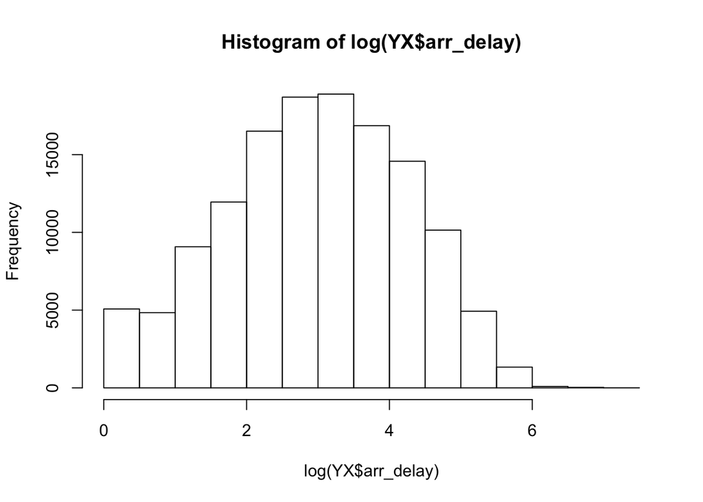

```r
hist(log(YX$arr_delay))
```

```r
YX[c("year","month","day","hour","dep_time","sched_dep_time","dep_delay","arr_time","sched_arr_time","arr_delay","air_time","distance","minute","temp", "dewp", "humid","wind_dir","wind_speed","wind_gust","precip","pressure","visib")][is.na(
  YX[c("year","month","day","hour","dep_time","sched_dep_time","dep_delay","arr_time","sched_arr_time","arr_delay","air_time","distance","minute","temp", "dewp", "humid","wind_dir","wind_speed","wind_gust","precip","pressure","visib")]
)] <- 0

cor(YX[c("dep_time","sched_dep_time","dep_delay","arr_time","sched_arr_time","arr_delay","air_time","distance","temp","dewp","humid","wind_dir","wind_speed","wind_gust","precip","pressure","visib")])
```

```
##                   dep_time sched_dep_time   dep_delay    arr_time
## dep_time        1.00000000    0.845323165  0.25806828  0.71016748
## sched_dep_time  0.84532317    1.000000000  0.19370742  0.55682342
## dep_delay       0.25806828    0.193707420  1.00000000  0.04175037
## arr_time        0.71016748    0.556823421  0.04175037  1.00000000
## sched_arr_time  0.69511886    0.783342477  0.15637120  0.69230997
## arr_delay       0.22226581    0.170138337  0.90934833  0.03245421
## air_time        0.08250030   -0.027632384 -0.01279395  0.15026404
## distance        0.01683888   -0.017994960 -0.01779433  0.07318801
## temp            0.16902026    0.192063877  0.08796742  0.10919614
## dewp           -0.03110003   -0.017412134  0.09799197 -0.06368330
## humid          -0.36792466   -0.376853502  0.05298993 -0.32948272
## wind_dir        0.06043948    0.050187993 -0.02927312  0.05726753
## wind_speed      0.09486079    0.121550559  0.03266848  0.06419301
## wind_gust       0.09486078    0.121550570  0.03266848  0.06419301
## precip         -0.02241037   -0.006967300  0.05559246 -0.03529017
## pressure        0.03176944   -0.002461354 -0.10530042  0.04743181
## visib           0.06400535    0.025835808 -0.10542468  0.07385237
##                sched_arr_time   arr_delay     air_time     distance
## dep_time          0.695118857  0.22226581  0.082500297  0.016838883
## sched_dep_time    0.783342477  0.17013834 -0.027632384 -0.017994960
## dep_delay         0.156371196  0.90934833 -0.012793949 -0.017794327
## arr_time          0.692309966  0.03245421  0.150264037  0.073188013
## sched_arr_time    1.000000000  0.13037689  0.064154986  0.068725917
## arr_delay         0.130376888  1.00000000 -0.027356549 -0.059441041
## air_time          0.064154986 -0.02735655  1.000000000  0.964226956
## distance          0.068725917 -0.05944104  0.964226956  1.000000000
## temp              0.156490417  0.05868436 -0.033773769  0.010870464
## dewp             -0.031480790  0.08366215 -0.026261275  0.021370782
## humid            -0.341529035  0.07535966  0.007902403  0.028681268
## wind_dir          0.043109974 -0.04064545  0.018521160  0.006416236
## wind_speed        0.100878065  0.03540097  0.002635960  0.003884702
## wind_gust         0.100878074  0.03540097  0.002635940  0.003884685
## precip           -0.007139767  0.06437339 -0.003559283  0.004916467
## pressure         -0.006677330 -0.11889641  0.021344145  0.008091452
## visib             0.016826060 -0.12893808  0.009686122 -0.002545733
##                        temp        dewp        humid     wind_dir
## dep_time        0.169020261 -0.03110003 -0.367924663  0.060439479
## sched_dep_time  0.192063877 -0.01741213 -0.376853502  0.050187993
## dep_delay       0.087967422  0.09799197  0.052989927 -0.029273115
```

[output cut: 35 more lines]

```
## dep_delay      -0.105424679
## arr_time        0.073852374
## sched_arr_time  0.016826060
## arr_delay      -0.128938083
## air_time        0.009686122
## distance       -0.002545733
## temp            0.110028721
## dewp           -0.112410612
## humid          -0.458311471
## wind_dir        0.210820487
## wind_speed      0.045575187
## wind_gust       0.045575154
## precip         -0.303638637
## pressure        0.492393947
## visib           1.000000000
```

```r
# removing arr_delay to see which features are highly correlated
correlationMatrix = cor(YX[c("dep_time","sched_dep_time","dep_delay","arr_time","sched_arr_time","air_time","distance","temp","dewp","humid","wind_dir","wind_speed","wind_gust","precip","pressure","visib")])
print(correlationMatrix)
```

```
##                   dep_time sched_dep_time   dep_delay    arr_time
## dep_time        1.00000000    0.845323165  0.25806828  0.71016748
## sched_dep_time  0.84532317    1.000000000  0.19370742  0.55682342
## dep_delay       0.25806828    0.193707420  1.00000000  0.04175037
## arr_time        0.71016748    0.556823421  0.04175037  1.00000000
## sched_arr_time  0.69511886    0.783342477  0.15637120  0.69230997
## air_time        0.08250030   -0.027632384 -0.01279395  0.15026404
## distance        0.01683888   -0.017994960 -0.01779433  0.07318801
## temp            0.16902026    0.192063877  0.08796742  0.10919614
## dewp           -0.03110003   -0.017412134  0.09799197 -0.06368330
## humid          -0.36792466   -0.376853502  0.05298993 -0.32948272
## wind_dir        0.06043948    0.050187993 -0.02927312  0.05726753
## wind_speed      0.09486079    0.121550559  0.03266848  0.06419301
## wind_gust       0.09486078    0.121550570  0.03266848  0.06419301
## precip         -0.02241037   -0.006967300  0.05559246 -0.03529017
## pressure        0.03176944   -0.002461354 -0.10530042  0.04743181
## visib           0.06400535    0.025835808 -0.10542468  0.07385237
##                sched_arr_time     air_time     distance         temp
## dep_time          0.695118857  0.082500297  0.016838883  0.169020261
## sched_dep_time    0.783342477 -0.027632384 -0.017994960  0.192063877
## dep_delay         0.156371196 -0.012793949 -0.017794327  0.087967422
## arr_time          0.692309966  0.150264037  0.073188013  0.109196136
## sched_arr_time    1.000000000  0.064154986  0.068725917  0.156490417
## air_time          0.064154986  1.000000000  0.964226956 -0.033773769
## distance          0.068725917  0.964226956  1.000000000  0.010870464
## temp              0.156490417 -0.033773769  0.010870464  1.000000000
## dewp             -0.031480790 -0.026261275  0.021370782  0.889672674
## humid            -0.341529035  0.007902403  0.028681268  0.082451388
## wind_dir          0.043109974  0.018521160  0.006416236 -0.086338165
## wind_speed        0.100878065  0.002635960  0.003884702 -0.064030200
## wind_gust         0.100878074  0.002635940  0.003884685 -0.064030269
## precip           -0.007139767 -0.003559283  0.004916467 -0.008908164
## pressure         -0.006677330  0.021344145  0.008091452  0.015801485
## visib             0.016826060  0.009686122 -0.002545733  0.110028721
##                       dewp        humid     wind_dir   wind_speed
## dep_time       -0.03110003 -0.367924663  0.060439479  0.094860787
## sched_dep_time -0.01741213 -0.376853502  0.050187993  0.121550559
## dep_delay       0.09799197  0.052989927 -0.029273115  0.032668482
## arr_time       -0.06368330 -0.329482717  0.057267533  0.064193012
## sched_arr_time -0.03148079 -0.341529035  0.043109974  0.100878065
```

[output cut: 13 more lines]

```
## sched_dep_time  0.121550570 -0.006967300 -0.002461354  0.025835808
## dep_delay       0.032668482  0.055592463 -0.105300419 -0.105424679
## arr_time        0.064193010 -0.035290174  0.047431808  0.073852374
## sched_arr_time  0.100878074 -0.007139767 -0.006677330  0.016826060
## air_time        0.002635940 -0.003559283  0.021344145  0.009686122
## distance        0.003884685  0.004916467  0.008091452 -0.002545733
## temp           -0.064030269 -0.008908164  0.015801485  0.110028721
## dewp           -0.119386518  0.072390459 -0.155371517 -0.112410612
## humid          -0.124584923  0.202356712 -0.360113648 -0.458311471
## wind_dir        0.192811749 -0.074824582  0.129801488  0.210820487
## wind_speed      1.000000000  0.016338054  0.013005075  0.045575187
## wind_gust       1.000000000  0.016338081  0.013005030  0.045575154
## precip          0.016338081  1.000000000 -0.153059485 -0.303638637
## pressure        0.013005030 -0.153059485  1.000000000  0.492393947
## visib           0.045575154 -0.303638637  0.492393947  1.000000000
```